# Hetorogeneous Treatment Effect Modeling on Forest Cover in 1986

Polina Koroleva

07 24 2019

This script runs heterogeneos treatment effect modeling of the protection policies effect on deforestation. This analysis is based on generalized random forest method (Athey, S., Tibshirani, J., & Wager, S., 2019). The analyses are carried out using the R package grf, version 0.10.3.

Generalized random forests (Athey, S., Tibshirani, J., & Wager, S., 2019) is a method for non-parametric statistical estimation based on random forests (Breiman, 2001) that can be used for estimating other statistical quantities besides the expected outcome. It addresses the problem of average treatment effect estimation based on a variant of augmented inverse-propensity weighting.

Causal forest method trains a model optimized on a treatment’s causal effect. Unlike random forest model that predicts the outcome μ(x)=Ε[Yi |Xi =x], generalized random forest extends this idea to allow for estimating other statistical quantities. In particular, causal forest estimates conditional average treatment effectsτ CATE =Ε[Yi(1)−Yi(0)] after being conditioned on the covariate (Yi(1) - the outcome of treated unit, Yi(0) - the outcome of control unit) . The method allows to select sub populations with different average treatment effects and to test hypotheses about the differences between the effects in different subpopulations (Athey and Imbens, 2015).Thus, it allows to evaluate the heterogeneity of the treatment among different groups.

The objective of causal forest analysis is to provide heterogeneous treatment effect estimation that yields valid asymptotic confidence intervals for the true underlying treatment effect. (Athey and Wager, 2019). The model is used to analyze the effectiveness of protection policy efforts. The motivation for building such model is to be able to design and target an intervention to maximize outcome. In this case, to evaluate the effect of protection policies on deforestation rate among the protected land units.

### Heterogeneous treatment effect modeling for protection policy evaluation

Generalized random forest by Athey et al (2019) is applied to the data collected in Costa Rica trough 1960-1986. In the causal forest analysis, the model is trained on the expected HTE for every forest parcel and then applied to future potential targets. As a result, it allows to predict which areas will benefit the most from protection.

##### Upload the libraries

```r
# The versions of the libraries are: "tidyverse" 0.2.1, "grf" 0.10.3, "ggplot2" 3.1.0
library(tidyverse)
library(ggplot2)
require(devtools)
library(grf)
```

##### Upload the matched data

This data set was created from original data by applying matching method. Matching is a neccesery procedure for studies with observational data: it is used to obtain groups of exposed and unexposed units and to ensure the compared units are as similar as possible.

In observational studies matching is determined by unconfoundness assumption (treatment Wi is independent of outcomes Yi (0) and) Yi (1) conditional on Xi. It holds true when treatment assignment is random conditional on Xi.

The script with matching is available at “~/Dropbox/ML Paper (Paul, Merlin, Polina)/Data & Code/Code”.

```r
load("matched_60.Rda")
```

##### Create randomized train and test sets

Matched data is randomized and split into the train and test subsets with 0.67 to 0.33 ratio. Such split rule is common for random forest algorithm and allowes to have enough data to train the model and then to test it.

```r
# Set seed for reproducibility of randomization
set.seed(123)
# Split the data to 0.67 for the train set and 0.33 to the test set. Randomize the forest units (rows)
ind_matched_60 <- sample(1:nrow(matched_60), size = round(0.33 * nrow(matched_60)))
# Create a train set
matched_train60 <- matched_60[-ind_matched_60, ]
# Create a test set
matched_test60 <- matched_60[ind_matched_60, ]

# Check the names of the columns
as.data.frame(colnames(matched_60))
```

```
##    colnames(matched_60)
## 1                   obs
## 2              match.id
## 3                for.97
## 4                  prot
## 5                dmcity
## 6                   drd
## 7             dfedge.60
## 8                luc123
## 9                  luc4
## 10               luc567
## 11                slope
## 12             prot.a80
## 13             for60per
## 14            luc123per
```

[output cut: 44 more lines]

Check the dimensions of the train and test data

```r
dim(matched_train60)
```

```
## [1] 6215   58
```

```r
dim(matched_test60)
```

```
## [1] 3061   58
```

##### Set up the variables for the analysis

The variables include: X - covariates; Y - the outcome; W - the treatment assignment In this study covariates are the forest characteristics, the outcome is deforestation of the unit (forested - 1, deforested - 0), treatment is protection policy (protected - 1, not protected - 0). Forest characteristics include both biophysical and socioeconomic covariates, for example distance to the nearest major city, slope and poverty indexes. The full definition of the variables is available at “~/Dropbox/ML Paper (Paul, Merlin, Polina)/Data & Code/Data”.

```r
# Create varibles from the train set
X <-matched_train60 [,c(5:57)]
Y <- matched_train60 [,c(3)]
W <- matched_train60[,c(4)]
```

##### Building the model

Build two separate forests to obtain Y.hat (conditional mean function E[Y | X = x]) and W.hat (residual tratment [W | X = x]). Then the model is trained on these residuals.

```r
# For Y forest, in order to get a better predictive performance in the presence of strong, smooth effect, the local linear forest is applied. It enables to improve on asymptotic rates of convergence for random forests with smooth signals, and provides substantial gains in accuracy (Friedberg, Tibshirani, Athey, 2018).
Y.forest = ll_regression_forest(X,Y)
Y.hat = predict(Y.forest)$predictions
# Separately build W.forest - regression forest for treatment and covariates.
W.forest = regression_forest(X,W)
W.hat = predict (W.forest)$predictions
```

Build a pilot causal forest, that includes all feautures, Y.hat and W.hat obtained in the previous step. The causal forest is honest (honesty = TRUE). That means that the training subsample is automaticaly split in half - first half is used to grow a tree and the second half is then used to make predictions at the leaves of the tree (Wager & Athey, 2018)

```r
# Set seed for repoducibility
set.seed(123)
# Build the pilot model
cf.raw = causal_forest(X,Y,W, Y.hat = Y.hat, W.hat = W.hat, honesty = TRUE)
# Rank the variables on their importance for the CATE estimation
varimp = variable_importance(cf.raw)
# Select the most important variables (the most accurate indicators of treatment effect)
selected.idx = which (varimp > mean(varimp))
```

##### Rank variables importance

List the features X that proved to be the most useful for heterogeneous treatment analysis. If the estimates of Y.hat and W.hat are good, then the confounding effects are eliminated and we can focus only on the features that are ranked as better treatment modifiers (Athey and Wager, 2019).

```r
# Make a dataframe with the ranked features X
cf.raw %>%
  variable_importance() %>%
  as.data.frame() %>%
  mutate(variable = colnames(cf.raw$X.orig))%>%
  arrange(desc(V1))
```

```
##             V1            variable
## 1  0.065621434                 drd
## 2  0.053766115                luc4
## 3  0.051495930             luc4per
## 4  0.050437896        clpovindex73
## 5  0.049225076            for60per
## 6  0.045429180            popden73
## 7  0.039180282      pct.nohotwat73
## 8  0.036169642      nohotwater.v73
## 9  0.032055705           luc123per
## 10 0.030220543     waterpuboth.v73
## 11 0.030198896           luc567per
## 12 0.029676748           dfedge.60
## 13 0.029302409   pct.waterpuboth73
## 14 0.026574524         noelect.v73
```

[output cut: 39 more lines]

Look at how many variables were selected as the most important features that will be used in the analysis.

```r
dim(X[,selected.idx])
```

```
## [1] 6215   19
```

Train the final causal forest using the selected features and make predictions on the test set. Compare the results with the predictions made by the original model with all variables X.

```r
# Train conditional forest on the selected features. The model is trained on the train set
set.seed(123)
cf = causal_forest (X[,selected.idx], Y, W,
                    Y.hat = Y.hat, W.hat = W.hat, honesty = TRUE)

# Make out-of-bag predictions using cf.raw (model with all variables) and cf (model with only selected variables) on the train set
tau.hat_cf.raw = predict(cf.raw)$predictions
tau.hat_cf = predict(cf)$predictions

# Make predictions on the test set using cf.raw (model with all variables) and cf (model with selected variables)
predictions_cf.raw = predict(cf.raw, matched_test60 [,c(5:57)], estimate.variance = TRUE)$predictions
predictions_cf = predict(cf, matched_test60 [,c(names(X[,selected.idx]))], estimate.variance = TRUE)$predictions
```

#### Omnibus tests for heterogeneity

Evaluation of predictive quality and heterogeneity is motivated by the “best linear predictor” method of Chernozhukov, Demirer, Duflo, and Fernandez-Val (2018), that seeks to fit the CATE as a linear function of the out-of-bag causal forest estimates τ^(− i)( X i).

“The function computes the best linear fit of the target estimand using the forest prediction (on held-out data) as well as the mean forest prediction as the sole two regressors. A coefficient of 1 for ‘mean.forest.prediction‘ suggests that the mean forest prediction is correct, whereas a coefficient of 1 for ‘differential.forest.prediction‘ additionally suggests that the forest has captured heterogeneity in the underlying signal. The p-value of the ‘differential.forest.prediction‘ coefficient also acts as an omnibus test for the presence of heterogeneity: If the coefficient is signif- icantly greater than 0, then we can reject the null of no heterogeneity”.(https://cran.r-project.org/web/packages/grf/grf.pdf)

```r
test_calibration(cf.raw)
```

```
##
## Best linear fit using forest predictions (on held-out data)
## as well as the mean forest prediction as regressors, along
## with one-sided heteroskedasticity-robust (HC3) SEs:
##
##                                Estimate Std. Error t value    Pr(>t)
## mean.forest.prediction          0.94655    0.14706  6.4364 6.573e-11 ***
## differential.forest.prediction  1.45166    0.19908  7.2918 1.719e-13 ***
## ---
## Signif. codes:  0 '***' 0.001 '**' 0.01 '*' 0.05 '.' 0.1 ' ' 1
```

```r
test_calibration(cf)
```

```
##
## Best linear fit using forest predictions (on held-out data)
## as well as the mean forest prediction as regressors, along
## with one-sided heteroskedasticity-robust (HC3) SEs:
##
##                                Estimate Std. Error t value    Pr(>t)
## mean.forest.prediction          0.88893    0.15718  5.6556 8.113e-09 ***
## differential.forest.prediction  1.49926    0.20418  7.3427 1.181e-13 ***
## ---
## Signif. codes:  0 '***' 0.001 '**' 0.01 '*' 0.05 '.' 0.1 ' ' 1
```

The results show that the `cf.raw` model got slightly better results for both `mean.forest.prediction` and `dofferential.forest.prediction`. It predicts CATE very well but underestimates the heterogeneity . If running analysis with all variables is expensive, the `cf` model with only the best treatment modifiers could be used. However, in order to maximize predictive quality of with of the model, `cf.raw` model that was built using all the variables will be used for the analysis.

##### Plot treatment effect distribution for the train and test sets

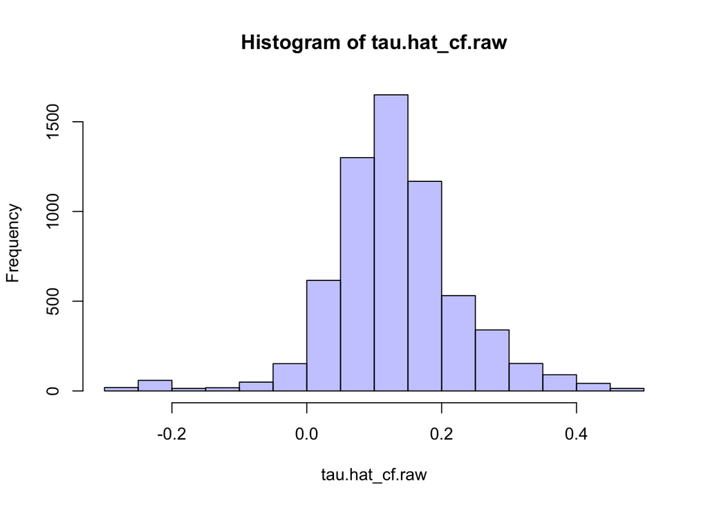

```r
# Compare out-of-bag treatment effect (tau.hat) distribution with the predicted treatment effect made on the separate test set (predictions).

# Histogram of the treatment effect obtained with the original model (cf.raw)
hist(tau.hat_cf.raw, col=rgb(0,0,1,1/4)) # train set
```

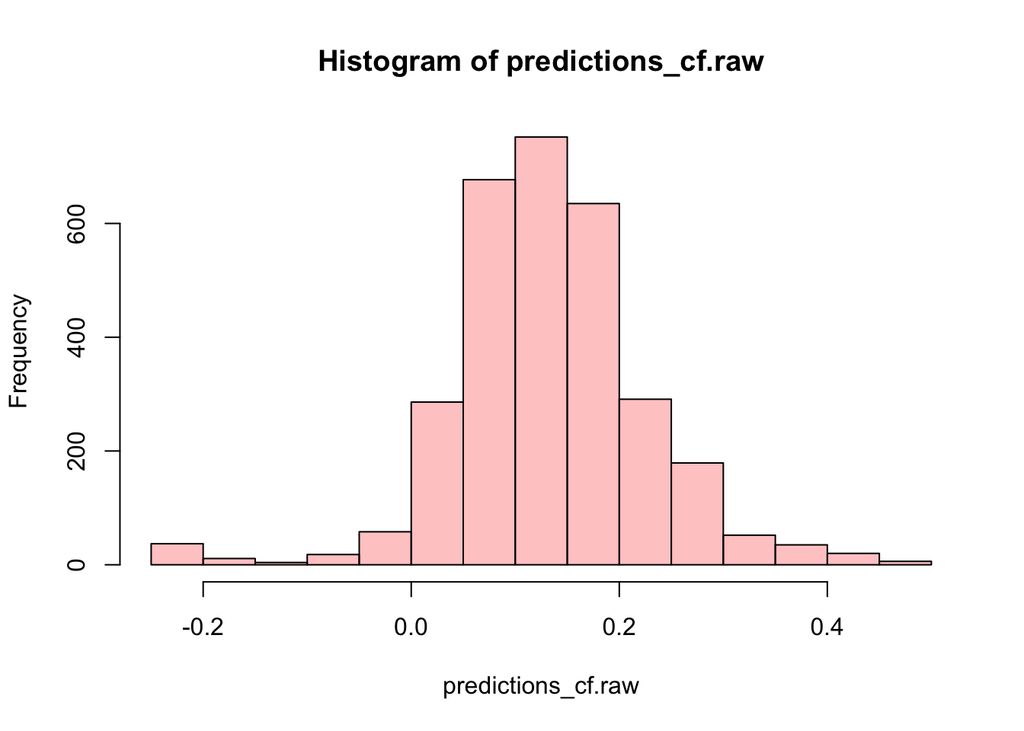

```r
hist(predictions_cf.raw, col=rgb(1,0,0,1/4)) # test set
```

The graphs look consistent with each other. To make the comparison easier, obtained treatment effect is split intro quantiles and then plot together for both out-of-bag train and test sets. The consistensy of the treatment effect estimates shows the good prediction quality of the model.

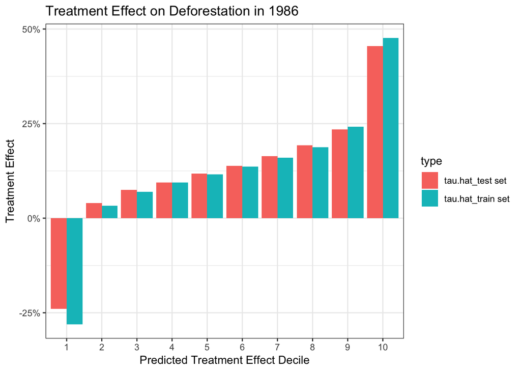

The plot also shows significant heterogeneity in the treatment effect. The next step is to estimate conditional average treatment effect and to evaluate the heterogeneity

#### Conditional average treatment effect (CATE)

Calculate CATE over all population and CATT over treated units. CATE overlap is used to obtain CATE when the propensity score is not bounded away from 0 and 1.

```r
ATE = average_treatment_effect(cf.raw)
paste("95% CI for the ATE:", round(ATE[1], 3),
      "+/-", round(qnorm(0.975) * ATE[2], 3))
```

```
## [1] "95% CI for the ATE: 0.131 +/- 0.016"
```

```r
ATT = average_treatment_effect(cf.raw, target.sample = "treated")
paste("95% CI for the ATT:", round(ATT[1], 3),
      "+/-", round(qnorm(0.975) * ATT[2], 3))
```

```
## [1] "95% CI for the ATT: 0.122 +/- 0.032"
```

```r
ATEO = average_treatment_effect(cf.raw, target.sample = "overlap")
paste("95% CI for the ATE overlap:", round(ATEO[1], 3),
      "+/-", round(qnorm(0.975) * ATEO[2], 3))
```

```
## [1] "95% CI for the ATE overlap: 0.14 +/- 0.04"
```

#### Heterogeneity evaluation

Evaluation of the treatment effect heterogeneity is obtained by calculating the difference between the highest and the lowest estimates of CATE.

```r
# The _train_ set is split into two: subset wih the CATE above the median and subset with the CATE below the median. The CATE are calculated for each of the subsets.
high_effect = tau.hat_cf.raw > median (tau.hat_cf.raw)
ate.high = average_treatment_effect (cf, subset = high_effect)
ate.low = average_treatment_effect (cf, subset = !high_effect)
ate.high
```

```
##  estimate   std.err
## 0.1912577 0.0134631
```

```r
ate.low
```

```
##   estimate    std.err
## 0.05038795 0.01035104
```

```r
# Compare regions with high and low estimated CATEs. This is an indicator of heterogeneity of the treatment effect
paste("95% CI for difference in ATE (high and low):",
      round(ate.high[1] - ate.low[1], 3), "+/-",
      round(qnorm(0.975) * sqrt(ate.high[2]^2 + ate.low[2]^2), 3))
```

```
## [1] "95% CI for difference in ATE (high and low): 0.141 +/- 0.033"
```

### Targetting units with the highest CATE vs targeting random

For the application purposes, it is useful to know how much more effective it is to follow the recommendations of this model versus randomly protecting forest units. To test this, we look at the CATE of protection policy on the half of the units picked in random compare to the effect on units with highest CATE.

```r
# Compare regions with high estimated CATEs and random (on train set)
set.seed(123) # reproducibility
random_sample = sample(c(TRUE,FALSE),6215, TRUE) # randomize the CATE
cf.raw$random_sample <- random_sample
ate.random = average_treatment_effect(cf.raw, subset = random_sample, target.sample="control")

paste("95% CI for difference in ATE in test set (high and random):",
      round(ate.high[1] - ate.random[1], 3), "+/-",
      round(qnorm(0.975) * sqrt(ate.high[2]^2 + ate.random[2]^2), 3))
```

```
## [1] "95% CI for difference in ATE in test set (high and random): 0.055 +/- 0.052"
```

##### Treatment effect comparison using regression

##### Train set

Evaluation of treatment effect heterogeneity using linear regression. Compare targeting the half of the forest units with biggest predicted treatment effect with the treatment effect on a random half of the sample using regression.

```r
# Train set
# Highest treatment effect
matched_train60$preds<-tau.hat_cf.raw
lm1<- lm (for.97 ~ prot, matched_train60[matched_train60$preds > median(matched_train60$preds), ])
summary(lm1)$coef
```

```
##              Estimate Std. Error  t value     Pr(>|t|)
## (Intercept) 0.4926254 0.01053106 46.77834  0.00000e+00
## prot        0.3770630 0.01562159 24.13730 4.07368e-118
```

```r
# Smallest treatment effect
lm2 <- lm(for.97 ~ prot, matched_train60[matched_train60$preds < median(matched_train60$preds), ])
summary(lm2)$coef
```

```
##                  Estimate  Std. Error      t value  Pr(>|t|)
## (Intercept)  0.8927576602 0.008176537 109.18530566 0.0000000
## prot        -0.0004775884 0.011149408  -0.04283531 0.9658356
```

```r
# Random half of the sample
set.seed(123)
cases11<- sample(1:nrow(matched_train60), size = round(0.5 * nrow(matched_train60)))
lm3 <- lm(for.97 ~ prot,
          matched_train60[cases11, ])
summary(lm3)$coef
```

```
##              Estimate Std. Error  t value     Pr(>|t|)
## (Intercept) 0.6696716 0.01017733 65.80030 0.000000e+00
## prot        0.2171451 0.01438829 15.09179 1.018717e-49
```

##### Test set

```r
# Test set
# Results for targeting the half of the sample with biggest predicted treatment effect
matched_test60$preds<-predictions_cf.raw
lm11 <- lm(for.97 ~ prot, matched_test60[matched_test60$preds > median(matched_test60$preds), ])
summary(lm11)$coef
```

```
##              Estimate Std. Error  t value      Pr(>|t|)
## (Intercept) 0.4706633 0.01465055 32.12597 1.868282e-173
## prot        0.4381839 0.02098120 20.88460  2.077857e-85
```

```r
# Results for targeting the half of the sample with SMALLEST predicted treatment effect
lm22 <- lm(for.97 ~ prot, matched_test60[matched_test60$preds < median(matched_test60$preds), ])
summary(lm22)$coef
```

```
##                Estimate Std. Error    t value  Pr(>|t|)
## (Intercept)  0.89473684 0.01170175 76.4618134 0.0000000
## prot        -0.01107348 0.01610241 -0.6876908 0.4917519
```

```r
#Compare to naive targeting
set.seed(1839)
cases1<- sample(1:nrow(matched_test60), size = round(0.5 * nrow(matched_test60)))
lm33 <- lm(for.97 ~ prot,
         matched_test60[cases1, ])
summary(lm33)$coef
```

```
##              Estimate Std. Error  t value      Pr(>|t|)
## (Intercept) 0.6666667 0.01446864 46.07668 2.567104e-291
## prot        0.2302799 0.02018655 11.40759  5.497498e-29
```

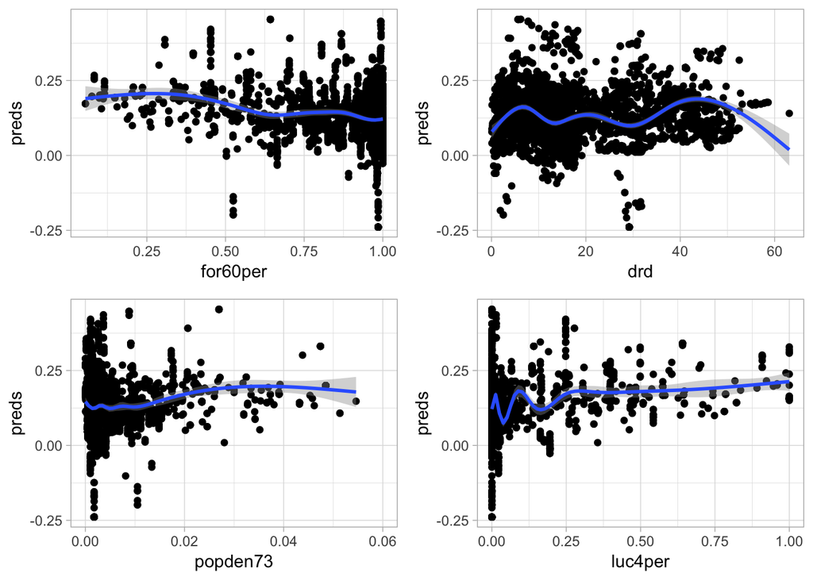

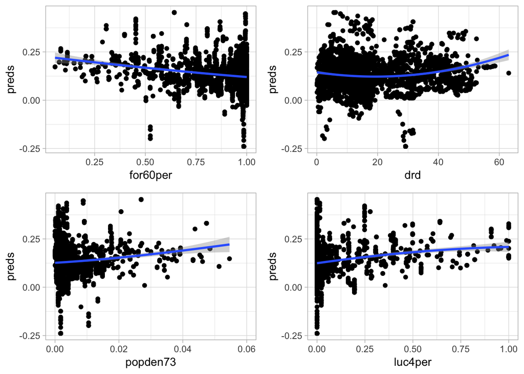

Moving further, the heterogeneity of the effect is evaluated graphically. Plot predicted treatment effects by their rank.

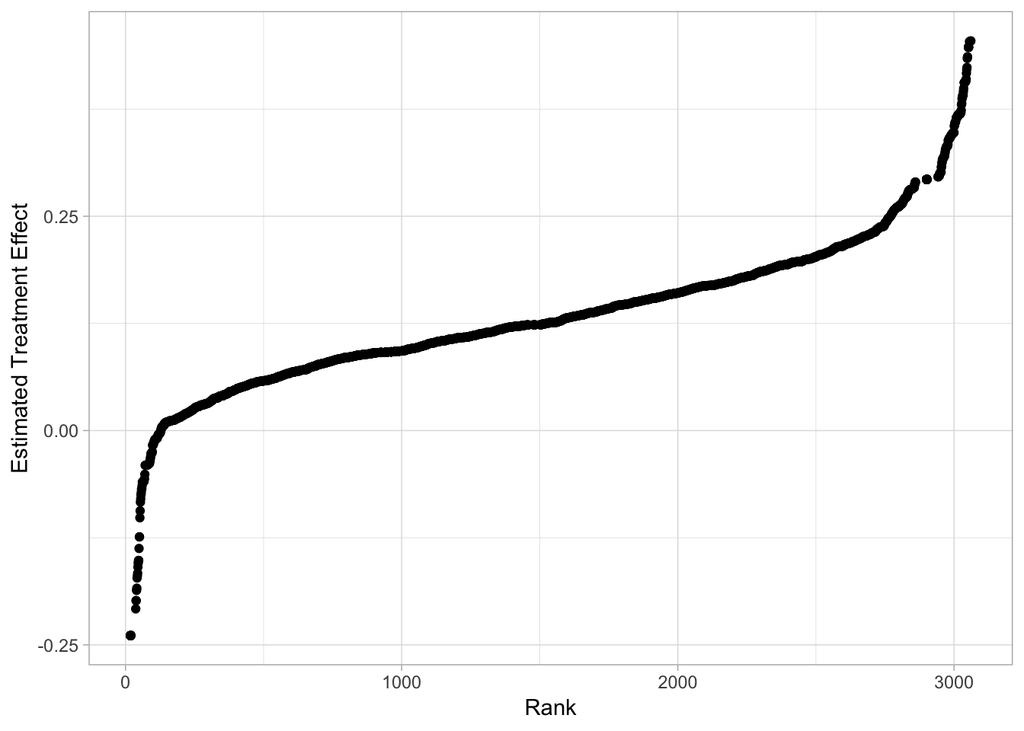

One more approach of HTE model evaluation consists of sorting treated and control test observations in ascending order of predicted uplift, separately. Both groups are then binned into deciles and the model performance is evaluated through the pairwise difference in the uplift average per decile.

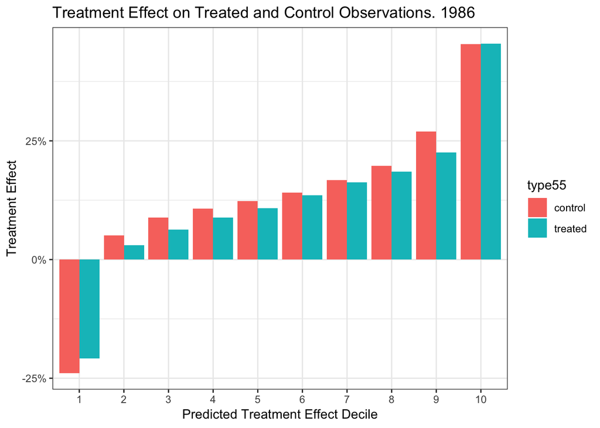

```r
# Get all the treated variables in a separate dataset
treated<- matched_test60[matched_test60$prot == 1,c(59)] #1555
# All control variables in a separate dataset
untreated<-matched_test60[matched_test60$prot == 0,c(59)] #1506
# Create quantiles from treated and control datasets (group data into 10 blocks)
treated<-quantile(treated, prob = seq(0, 1, length = 10), type = 5)
untreated<-quantile(untreated, prob = seq(0, 1, length = 10), type = 5)
# Combine treated and control groups in one dataset
df55<-c(treated, untreated)
# Create names for the treated and control units, put it in decile format
type55 <-c(rep("treated", 10), rep("control", 10))
# Create a column with decile numbers
decile<-(rep(1:10,2))
# Combine the columns in one data set
mydata55 <-data.frame(df55,decile,type55)

# Create ggplot with the data
p <-ggplot(mydata55, aes(x =factor(decile),df55))
p +geom_bar(stat = "identity", aes(fill = type55), position = "dodge")+
  scale_x_discrete (breaks = seq(1, 10, 1))+
  scale_y_continuous(labels=scales::percent)+
  ylab ("Treatment Effect")+
  xlab("Predicted Treatment Effect Decile")+
  ggtitle("Treatment Effect on Treated and Control Observations. 1986") +
  theme_bw()
```

#### Dictionary

*Heterogeneous treatment effect* - variation in the response of the individuals (units) to the treatment.

*Honest trees* - the tree is honest if, for each training example i , it only uses the response Yi to estimate the within-leaf treatment effect τ or to decide where to place the splits, but not both. (Wager and Athey, 2018). This approach is used in to order to avoid overfitting and reduce bias in trees predictions

*Machine learning* - the task of extracting “implicit, previously unknown, and potentially useful information from data”

*Matching* - a procedure that divides a group of N subjects into pairs to minimize covariate differences within pairs. A method that aims to equate the distribution of covariates in the treated and control groups.

*Out-of-bag estimate* - prediction error calculation on the training set, by only including the trees in the calculation of a row’s error where that row was not included in training that tree. This allows to see whether the model is over-fitting, without needing a separate validation set.

#### References

Athey, S., & Imbens, G. W. (2015). Machine Learning Methods for Estimating Heterogeneous Causal Effects *. Retrieved from arxiv.org/pdf/1504.01132v1.pdf

Athey, S., Tibshirani, J., & Wager, S. (2019). Generalized random forests. The Annals of Statistics, 47(2), 1148–1178. https://doi.org/10.1214/18-AOS1709

Athey, S., & Wager, S. (2019). Estimating Treatment Effects with Causal Forests: An Application. Retrieved from arxiv.org/pdf/1902.07409.pdf

Chernozhukov, V., Demirer, M., Duflo, E., & Fernandez-Val, I. (2018.). Generic Machine Learning Inference on Heterogenous Treatment Effects in Randomized Experiments. Retrieved from arxiv.org/pdf/1712.04802.pdf

Friedberg, R., Tibshirani, J., Athey, S., & Wager, S. (2018). Local Linear Forests. Retrieved from gssdataexplorer.norc.org/variables/191/vshow

Gutierrez, P., & Gérardy, J.-Y. (2016). Causal Inference and Uplift Modeling A review of the literature (Vol. 67). Retrieved from proceedings.mlr.press/v67/gutierrez17a/gutierrez17a.pdf

Wager, S., & Athey, S. (2018). Estimation and Inference of Heterogeneous Treatment Effects using Random Forests. Journal of the American Statistical Association, 113(523), 1228–1242. https://doi.org/10.1080/01621459.2017.1319839

White H. White (2018). Explicitly Optimizing on Causal Effects via the Causal Random Forest: A Practical Introduction and Tutorial. URL: www.Markhw.Com/blog/causalforestintro. Accessed on 9 May 2019